# TO414 HW 8 - Based on A Final Assessment

Jake Close & Peter Kaplan

Dec 01, 2017

> Welcome to TO414 Advanced Analytics Homework 8. This is loosely based on the final assessment for one of the prior offerings of thc course. For this submission, you should edit this RMD file to build your submission. Once you are done, please submit the RMD file and the HTML output on Canvas. **Please make your output readable** - put sufficient amount of comment and text explanation so that you can receive partial credits even if you could not finish a task. Have fun!

## Problem Statement

You are a member of the consulting team that is working with a client to boost their HR system. A key pain point for the client is the fact that employees have been leaving the company. They would like to identify which employees are likely to leave so that they can have their HR managers work with those employees in an effort to retain them. To help you in that effort, they have given you all the information they have on their employees including which of them left the company. **You are asked to explore the data and build a predictive model that can accurately predict which employees are likely to quit the company.**

## Data Import and Cleaning

Your first task is to import the data into R and check whether any data cleaning is needed. The data is available in a file named *hrdata.csv*. You should carefully consider whether all variables are in the correct class, whether there are missing values that need your attention, are there any other issues in the data that you need to consider?

```r
suppressPackageStartupMessages(require(class))
suppressPackageStartupMessages(require(gmodels))
suppressPackageStartupMessages(require(stats))
suppressPackageStartupMessages(require(magrittr))
suppressPackageStartupMessages(require(caret))
suppressPackageStartupMessages(library(kernlab))
suppressPackageStartupMessages(library(neuralnet))
suppressPackageStartupMessages(library(randomForest))
suppressPackageStartupMessages(library(ada))
library(dummies)
```

```r
library(class)
library(gmodels)
library(ggplot2)
library(dplyr)
library(C50)
```

```r
#Insert your code for data import and cleaning here
hr <- read.csv("hrdata.csv")

#X looks like a unique ID, lets drop
hr <- hr[-1]
str(hr)
```

```
## 'data.frame':    14999 obs. of  10 variables:
##  $ satisfaction_level   : num  0.38 0.8 0.11 0.72 0.37 0.41 0.1 0.92 0.89 0.42 ...
##  $ last_evaluation      : num  0.53 0.86 0.88 0.87 0.52 0.5 0.77 0.85 1 0.53 ...
##  $ number_project       : int  2 5 7 5 2 2 6 5 5 2 ...
##  $ average_montly_hours : int  157 262 272 223 159 153 247 259 224 142 ...
##  $ time_spend_company   : int  3 6 4 5 3 3 4 5 5 3 ...
##  $ Work_accident        : int  0 0 0 0 0 0 0 0 0 0 ...
##  $ left                 : int  1 1 1 1 1 1 1 1 1 1 ...
##  $ promotion_last_5years: int  0 0 0 0 0 0 0 0 0 0 ...
##  $ sales                : Factor w/ 10 levels "accounting","hr",..: 8 8 8 8 8 8 8 8 8 8 ...
##  $ salary               : Factor w/ 3 levels "high","low","medium": 2 3 3 2 2 2 2 2 2 2 ...
```

```r
summary(hr)
```

```
##  satisfaction_level last_evaluation  number_project  average_montly_hours
##  Min.   :0.0900     Min.   :0.3600   Min.   :2.000   Min.   : 96.0
##  1st Qu.:0.4400     1st Qu.:0.5600   1st Qu.:3.000   1st Qu.:156.0
##  Median :0.6400     Median :0.7200   Median :4.000   Median :200.0
##  Mean   :0.6128     Mean   :0.7161   Mean   :3.803   Mean   :201.1
##  3rd Qu.:0.8200     3rd Qu.:0.8700   3rd Qu.:5.000   3rd Qu.:245.0
##  Max.   :1.0000     Max.   :1.0000   Max.   :7.000   Max.   :310.0
##
##  time_spend_company Work_accident         left
##  Min.   : 2.000     Min.   :0.0000   Min.   :0.0000
##  1st Qu.: 3.000     1st Qu.:0.0000   1st Qu.:0.0000
##  Median : 3.000     Median :0.0000   Median :0.0000
##  Mean   : 3.498     Mean   :0.1446   Mean   :0.2381
##  3rd Qu.: 4.000     3rd Qu.:0.0000   3rd Qu.:0.0000
##  Max.   :10.000     Max.   :1.0000   Max.   :1.0000
##
##  promotion_last_5years         sales         salary
##  Min.   :0.00000       sales      :4140   high  :1237
##  1st Qu.:0.00000       technical  :2720   low   :7316
##  Median :0.00000       support    :2229   medium:6446
##  Mean   :0.02127       IT         :1227
##  3rd Qu.:0.00000       product_mng: 902
##  Max.   :1.00000       marketing  : 858
##                        (Other)    :2923
```

```r
hr$left <- as.factor(hr$left)
levels(hr$left) <- c("NO", "YES")
hr$Work_accident <- as.factor(hr$Work_accident)
levels(hr$Work_accident) <- c("NO", "YES")
hr$promotion_last_5years <- as.factor(hr$promotion_last_5years)
levels(hr$promotion_last_5years)  <- c("NO", "YES")
```

```
TODO: What data cleaning did you need to do? Explain in this text block.

We had to do very light data cleaning for this data set. We removed the unique identifier column. In addition we also turned leaving the company, having a work accident and having a promotion into a factor with levels of "Yes" and "No".
```

## Data Exploration

Before you get started on building your prediction model, you should explore the data to get a better understanding of the data. Such exploration may include calculating exploratory summary statistics, building interesting charts etc.

```r
#Insert your code for data exploration and visualization here

round(prop.table(table(hr$left)) * 100, 1)
```

```
##
##   NO  YES
## 76.2 23.8
```

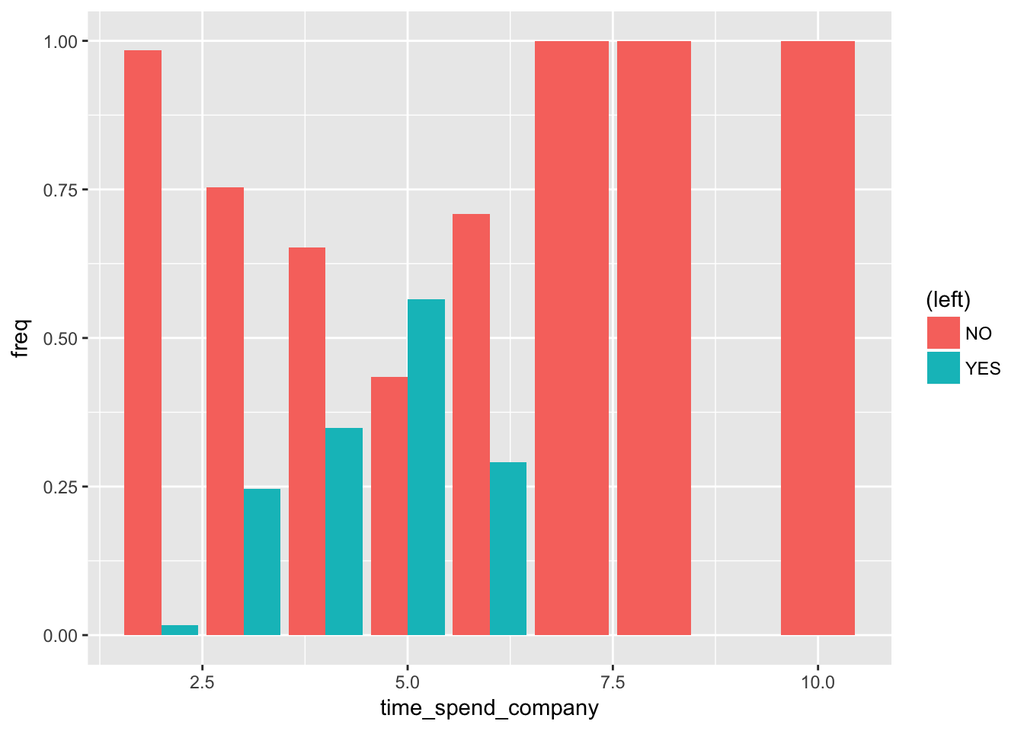

```r
leftByYear <- hr %>%
    group_by(time_spend_company, left) %>%
    summarise(count = n()) %>%
    mutate(freq = count / sum(count))




plot<-ggplot(data=leftByYear, aes(x=time_spend_company, y=freq, fill = (left)))+
  geom_bar(stat="identity" , position = "dodge")
plot
```

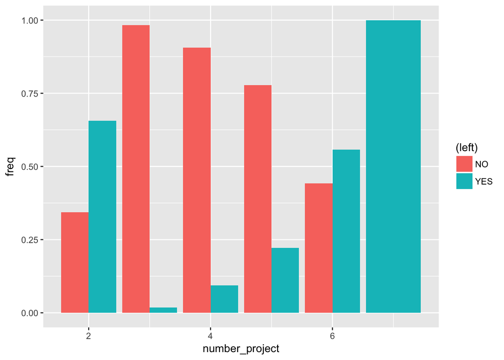

```r
leftByProject<- hr %>%
    group_by(number_project, left) %>%
    summarise(count = n()) %>%
    mutate(freq = count / sum(count))


plot<-ggplot(data=leftByProject, aes(x=number_project, y=freq, fill = (left)))+
  geom_bar(stat="identity" , position = "dodge")
plot
```

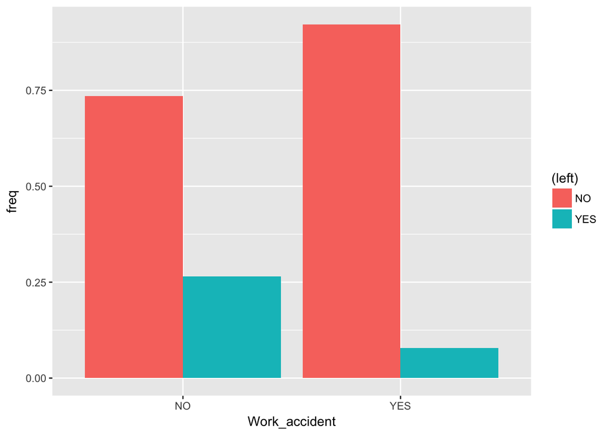

```r
leftByAccident<- hr %>%
    group_by(Work_accident, left) %>%
    summarise(count = n()) %>%
    mutate(freq = count / sum(count))



plot<-ggplot(data=leftByAccident, aes(x=Work_accident, y=freq, fill = (left)))+
  geom_bar(stat="identity" , position = "dodge")
plot
```

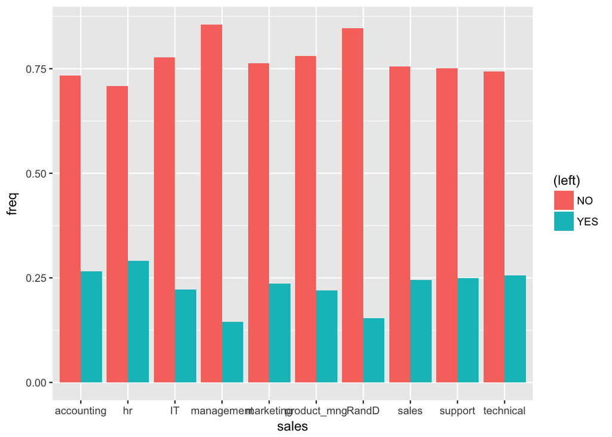

```r
leftByPosition<- hr %>%
    group_by(sales, left) %>%
    summarise(count = n()) %>%
    mutate(freq = count / sum(count))



plot<-ggplot(data=leftByPosition, aes(x=sales, y=freq, fill = (left)))+
  geom_bar(stat="identity" , position = "dodge")
plot
```

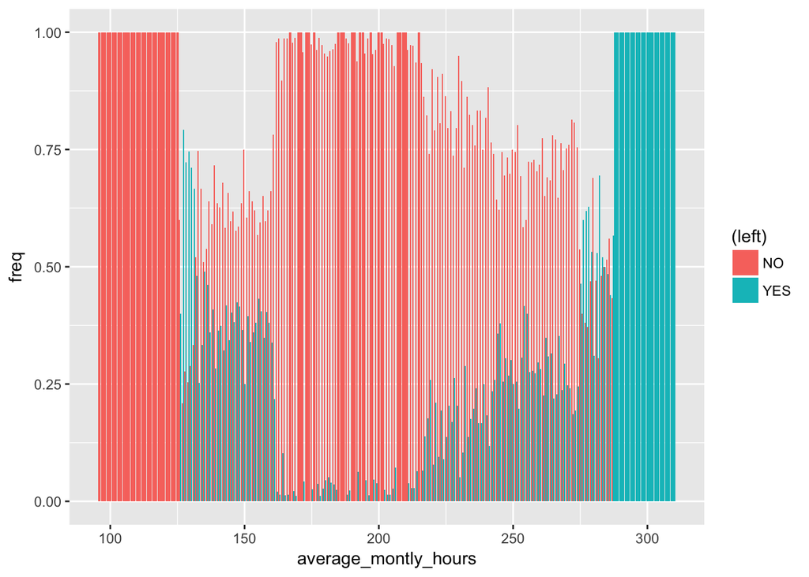

```r
leftByHours<- hr %>%
    group_by(average_montly_hours, left) %>%
    summarise(count = n()) %>%
    mutate(freq = count / sum(count))



plot<-ggplot(data=leftByHours, aes(x=average_montly_hours, y=freq, fill = (left)))+
  geom_bar(stat="identity" , position = "dodge")
plot
```

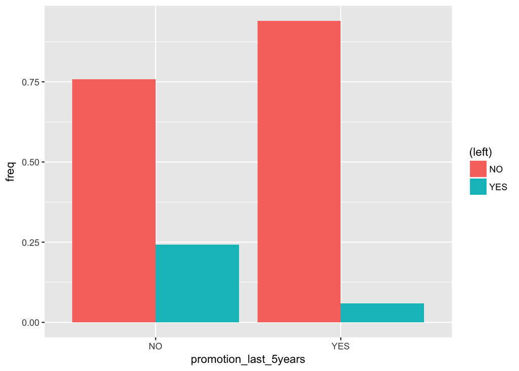

```r
leftByPromotion<- hr %>%
    group_by(promotion_last_5years, left) %>%
    summarise(count = n()) %>%
    mutate(freq = count / sum(count))



plot<-ggplot(data=leftByPromotion, aes(x=promotion_last_5years, y=freq, fill = (left)))+
  geom_bar(stat="identity" , position = "dodge")
plot
```

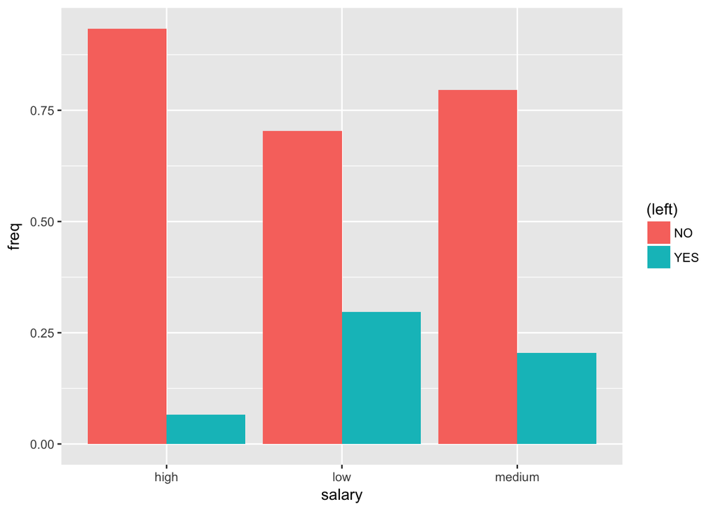

```r
leftBySalary<- hr %>%
    group_by(salary, left) %>%
    summarise(count = n()) %>%
    mutate(freq = count / sum(count))



plot<-ggplot(data=leftBySalary, aes(x=salary, y=freq, fill = (left)))+
  geom_bar(stat="identity" , position = "dodge")
plot
```

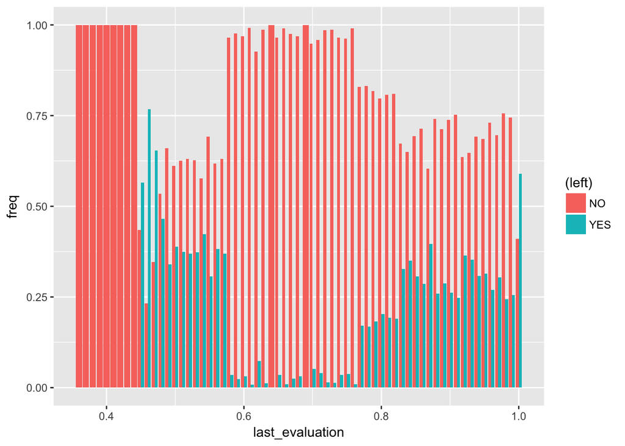

[output not shown]

```r
leftByEval<- hr %>%
    group_by(last_evaluation, left) %>%
    summarise(count = n()) %>%
    mutate(freq = count / sum(count))

plot<-ggplot(data=leftByEval, aes(x=last_evaluation, y=freq, fill = (left)))+
  geom_bar(stat="identity" , position = "dodge")
plot
```

## Building a Logistic Regression Model

Lets start with a Logistic Regression Model as the base model. You should carefully consider whether you need some interaction effects in your model.

```r
#Insert your code for building a logistic regression model here
library(VGAM)
library(lmtest)
library(aod)
library(caret)
   hr_formula <- colnames(hr) %>%
    {paste(.[! . %in% "left"], collapse = " + ")} %>%
    paste("left ~ ", .) %>%
    as.formula()

    train_data <- hr[0:12000, ]
    test_data <- hr[12001:14999, ]

    log_model <- glm(left ~ ., data = train_data, family = "binomial")
  # Create a step logistic to factor in all of the necessary variables
     summary(log_model)
```

```
##
## Call:
## glm(formula = left ~ ., family = "binomial", data = train_data)
##
## Deviance Residuals:
##     Min       1Q   Median       3Q      Max
## -2.1595  -0.5658  -0.3614  -0.1921   3.1555
##
## Coefficients:
##                            Estimate Std. Error z value Pr(>|z|)
## (Intercept)              -2.0505718  0.2521011  -8.134 4.16e-16 ***
## satisfaction_level       -4.0226715  0.1211739 -33.198  < 2e-16 ***
## last_evaluation           0.5962296  0.1800562   3.311 0.000928 ***
## number_project           -0.2886107  0.0258907 -11.147  < 2e-16 ***
## average_montly_hours      0.0041173  0.0006216   6.624 3.51e-11 ***
## time_spend_company        0.3079136  0.0202271  15.223  < 2e-16 ***
## Work_accidentYES         -1.4429068  0.1109351 -13.007  < 2e-16 ***
## promotion_last_5yearsYES -1.4628025  0.3843782  -3.806 0.000141 ***
## saleshr                   0.1377605  0.1657808   0.831 0.405985
## salesIT                  -0.0191346  0.1525542  -0.125 0.900184
## salesmanagement          -0.2295874  0.2024092  -1.134 0.256680
## salesmarketing            0.0405011  0.1662055   0.244 0.807478
## salesproduct_mng         -0.0344749  0.1646693  -0.209 0.834168
## salesRandD               -0.3495131  0.1733268  -2.016 0.043748 *
## salessales                0.0561511  0.1290379   0.435 0.663452
## salessupport              0.1173290  0.1370692   0.856 0.392007
## salestechnical            0.0839353  0.1337196   0.628 0.530203
## salarylow                 1.8386550  0.1638898  11.219  < 2e-16 ***
## salarymedium              1.3844728  0.1647690   8.403  < 2e-16 ***
## ---
## Signif. codes:  0 '***' 0.001 '**' 0.01 '*' 0.05 '.' 0.1 ' ' 1
##
## (Dispersion parameter for binomial family taken to be 1)
##
##     Null deviance: 10813.5  on 11999  degrees of freedom
## Residual deviance:  8602.1  on 11981  degrees of freedom
## AIC: 8640.1
##
## Number of Fisher Scoring iterations: 6
```

```r
    log_model_step <- glm(left~ 1, data = train_data, family = binomial)
  log_model_step <- step(log_model_step, scope = (hr_formula), direction = "forward")
```

```
## Start:  AIC=10815.47
## left ~ 1
##
##                         Df Deviance     AIC
## + satisfaction_level     1   9375.6  9379.6
## + time_spend_company     1  10499.5 10503.5
## + Work_accident          1  10578.9 10582.9
## + salary                 2  10606.6 10612.6
## + average_montly_hours   1  10756.9 10760.9
## + promotion_last_5years  1  10780.7 10784.7
## + number_project         1  10803.5 10807.5
## + sales                  9  10791.6 10811.6
## <none>                      10813.5 10815.5
## + last_evaluation        1  10811.8 10815.8
##
## Step:  AIC=9379.64
## left ~ satisfaction_level
##
##                         Df Deviance    AIC
## + Work_accident          1   9165.4 9171.4
## + salary                 2   9184.4 9192.4
## + time_spend_company     1   9234.1 9240.1
## + number_project         1   9343.5 9349.5
## + promotion_last_5years  1   9349.8 9355.8
## + average_montly_hours   1   9352.5 9358.5
## + last_evaluation        1   9365.1 9371.1
## + sales                  9   9353.2 9375.2
## <none>                       9375.6 9379.6
##
## Step:  AIC=9171.43
## left ~ satisfaction_level + Work_accident
##
##                         Df Deviance    AIC
## + salary                 2   8968.2 8978.2
## + time_spend_company     1   9010.3 9018.3
## + number_project         1   9134.5 9142.5
## + promotion_last_5years  1   9142.4 9150.4
## + average_montly_hours   1   9143.8 9151.8
## + last_evaluation        1   9154.0 9162.0
## + sales                  9   9144.3 9168.3
```

[output cut: 48 more lines]

```
##     number_project + average_montly_hours + promotion_last_5years
##
##                   Df Deviance    AIC
## + last_evaluation  1   8618.2 8638.2
## <none>                 8629.2 8647.2
## + sales            9   8613.0 8649.0
##
## Step:  AIC=8638.18
## left ~ satisfaction_level + Work_accident + salary + time_spend_company +
##     number_project + average_montly_hours + promotion_last_5years +
##     last_evaluation
##
##         Df Deviance    AIC
## <none>       8618.2 8638.2
## + sales  9   8602.1 8640.1
```

```r
  # Boosted Logistic Model
  #log_model_boosted <- caret::train(left ~ ., data = train_data,
  #                                  method = "LogitBoost",
  #                                  trcontrol = fitControl,
  #                                  metric = "Kappa")


  accuracy <- function(predicted, trueval, model, hideoutput = F) {
      stopifnot(length(predicted) == length(trueval))
      result <- sum(predicted == trueval) / length(predicted)
      if (!hideoutput) {cat("Model:", model, "had", result, "accuracy\n")}
      return(result)
    }

# ==========================================================
# Get the various predictions for the test data
# ==========================================================
log_prediction <- predict(log_model, test_data, type = "response") %>% {ifelse(. > 0.5, "YES", "NO")} %>% as.factor()
  table(log_prediction)
```

```
## log_prediction
##   NO  YES
## 2547  452
```

```r
  a1 = accuracy(log_prediction, test_data$left, "Log Prediction Plain", TRUE)
```

```
How was your logisic model? Anything interesting there? Write your conclusions and insights from the Logistic Regression Model here.

Our logistic model was not very accurate. This stemmed from having multiple strong 3 star variables. One of the strongest indicator variables was satisfaction level. This intuitively makes sense because if someone is unhappy with their job they would want to leave and vice-versa.

A piece of data that was interesting was that job type has relatively low impact on if the person stays or leaves. The
most impactful job type was being in R & D and that was one star probability and people were more likely to stay. This might be because the people in that division were friendlier or the division cared more than others about work/life balance or culture than other groups in the company.
```

## Getting Data Ready for Machine Learning Models

Before we start running Machine Learning Models, we need to make sure that the data is randomized, is normalized and is divided into train and test samples.

```r
#Insert your code here for getting the data ready for Machine Learning Models

set.seed(12345)
hr_rand <- hr[order(runif(14999)),]
hr_dummy <-model.matrix(~ . -1, data = hr_rand)
hr_dummy <- as.data.frame(scale(hr_dummy))
# Rescale the data
#hr_dummy <- hr_dummy[-1]
hr_ran <- hr_dummy[order(runif(1232)), ]

#train_data_indicies <- sample(1:nrow(hr_dummy),
#                             replace = F,
 #                             size = floor(nrow(hr_dummy) * 0.8))
colnames(hr_dummy)[which(names(hr_dummy) == "leftYES")] <- "left"
#index <- createDataPartition()
train_data <- hr_dummy[1:12000, ]
test_data <- hr_dummy[12001:14999, ]

hr_formula <- colnames(hr_dummy) %>%
    {paste(.[! . %in% "left"], collapse = " + ")} %>%
    paste("left ~ ", .) %>%
    as.formula()
```

## Support Vector Machines

Build an SVM model to predict which employee will quit the company. You should build an SVM model with **vanilladot** and then one with **rbfdot**. Use the model to predict the test data. How good are your models? Calculate accuracy percentage and kappa statistics for your models.

```r
train_data$left <- ifelse(train_data$left  < 1 , "0", "1" )
train_data$left  <- as.factor(train_data$left )

test_data$left <- ifelse(test_data$left  < 1 , "0", "1")
test_data$left  <- as.factor(test_data$left )
#Insert code for SVM Models here
library(kernlab)
    svm_model_one <- ksvm(hr_formula, data = train_data, kernel = "vanilladot")
    svm_model_two <- ksvm(hr_formula, data = train_data, kernel = "rbfdot")

    svm_prediction_01 <- predict(svm_model_one, test_data)
    svm_prediction_02 <- predict(svm_model_two, test_data)
    a2 = accuracy(svm_prediction_01, test_data$left, "SVM with Vanilla Kernal", TRUE)
    a3 = accuracy(svm_prediction_02, test_data$left, "SVM Radial Basis Kernal", TRUE)

 library(vcd)
  Kappa(table(svm_prediction_01, test_data$left))
```

```
##             value     ASE     z Pr(>|z|)
## Unweighted 0.2363 0.01951 12.11 9.08e-34
## Weighted   0.2363 0.01951 12.11 9.08e-34
```

```r
  Kappa(table(svm_prediction_02, test_data$left))
```

```
##             value     ASE     z Pr(>|z|)
## Unweighted 0.8621 0.01079 79.87        0
## Weighted   0.8621 0.01079 79.87        0
```

[output not shown]

## Decision Trees

Build an Decision Tree model to predict which employee will quit the company. Use the model to predict the test data. How good is your model? Calculate accuracy percentage and kappa statistics for your models.

```r
#Insert your code to build a decision tree model here

tree_model <- C5.0(train_data[-8], train_data$left)
# display simple facts about the tree
tree_model
```

```
##
## Call:
## C5.0.default(x = train_data[-8], y = train_data$left)
##
## Classification Tree
## Number of samples: 12000
## Number of predictors: 19
##
## Tree size: 22
##
## Non-standard options: attempt to group attributes
```

```r
# display detailed information about the tree
summary(tree_model)
```

```
##
## Call:
## C5.0.default(x = train_data[-8], y = train_data$left)
##
##
## C5.0 [Release 2.07 GPL Edition]      Wed Dec  6 16:08:14 2017
## -------------------------------
##
## Class specified by attribute `outcome'
##
## Read 12000 cases (20 attributes) from undefined.data
##
## Decision tree:
##
## average_montly_hours > 1.720952: 1 (270)
## average_montly_hours <= 1.720952:
## :...number_project <= -1.462814:
##     :...satisfaction_level > -0.614701: 0 (507/26)
##     :   satisfaction_level <= -0.614701:
##     :   :...last_evaluation > -0.853552: 0 (109/5)
##     :       last_evaluation <= -0.853552:
##     :       :...last_evaluation <= -1.613035: 0 (33)
##     :           last_evaluation > -1.613035:
##     :           :...average_montly_hours > -0.8019193:
##     :               :...average_montly_hours <= 0.7798808: 0 (16)
##     :               :   average_montly_hours > 0.7798808:
##     :               :   :...average_montly_hours <= 1.140291: 1 (6)
##     :               :       average_montly_hours > 1.140291: 0 (3)
##     :               average_montly_hours <= -0.8019193:
##     :               :...average_montly_hours <= -1.482694:
##     :                   :...average_montly_hours <= -1.52274: 0 (9)
##     :                   :   average_montly_hours > -1.52274: 1 (56)
##     :                   average_montly_hours > -1.482694:
##     :                   :...satisfaction_level > -1.016904: 1 (1056/4)
##     :                       satisfaction_level <= -1.016904:
##     :                       :...satisfaction_level <= -1.097345: 0 (9/2)
##     :                           satisfaction_level > -1.097345: 1 (76)
##     number_project > -1.462814:
##     :...satisfaction_level <= -2.022412: 1 (467)
##         satisfaction_level > -2.022412:
```

[output cut: 28 more lines]

```
##    ----  ----
##    9152    22    (a): class 0
##     229  2597    (b): class 1
##
##
##  Attribute usage:
##
##  100.00% average_montly_hours
##   97.75% satisfaction_level
##   97.75% number_project
##   78.19% time_spend_company
##   28.07% last_evaluation
##
##
## Time: 0.1 secs
```

```r
## Step 4: Evaluating model performance ----
# create a factor vector of predictions on test data
tree_pred <- predict(tree_model, test_data)

# cross tabulation of predicted versus actual classes
library(gmodels)
CrossTable(test_data$left, tree_pred,
           prop.chisq = FALSE, prop.c = FALSE, prop.r = FALSE,
           dnn = c('actual left', 'predicted left'))
```

```
##
##
##    Cell Contents
## |-------------------------|
## |                       N |
## |         N / Table Total |
## |-------------------------|
##
##
## Total Observations in Table:  2999
##
##
##              | predicted left
##  actual left |         0 |         1 | Row Total |
## -------------|-----------|-----------|-----------|
##            0 |      2251 |         3 |      2254 |
##              |     0.751 |     0.001 |           |
## -------------|-----------|-----------|-----------|
##            1 |        60 |       685 |       745 |
##              |     0.020 |     0.228 |           |
## -------------|-----------|-----------|-----------|
## Column Total |      2311 |       688 |      2999 |
## -------------|-----------|-----------|-----------|
##
##
```

```r
a4 = accuracy(tree_pred, test_data$left, "Decision Tree", TRUE)

Kappa(table(tree_pred, test_data$left))
```

```
##             value      ASE     z Pr(>|z|)
## Unweighted 0.9423 0.007187 131.1        0
## Weighted   0.9423 0.007187 131.1        0
```

[output not shown]

### Improving Decision Trees: Boosting and Cost Matrix

Lets attempt to improve your decision tree model by adding Adaptive Boosting for 10 trials. Does that make a difference to your prediction accuracy?

```r
#Insert your code to build a decision tree model with 10 trials adaptive boosting here
left_boost100 <- C5.0(train_data[-8], train_data$left, trials = 10)
left_boost_pred100 <- predict(left_boost100, test_data)
CrossTable(test_data$left, left_boost_pred100,
           prop.chisq = FALSE, prop.c = FALSE, prop.r = FALSE,
           dnn = c('actual left', 'predicted left'))
```

```
##
##
##    Cell Contents
## |-------------------------|
## |                       N |
## |         N / Table Total |
## |-------------------------|
##
##
## Total Observations in Table:  2999
##
##
##              | predicted left
##  actual left |         0 |         1 | Row Total |
## -------------|-----------|-----------|-----------|
##            0 |      2243 |        11 |      2254 |
##              |     0.748 |     0.004 |           |
## -------------|-----------|-----------|-----------|
##            1 |        47 |       698 |       745 |
##              |     0.016 |     0.233 |           |
## -------------|-----------|-----------|-----------|
## Column Total |      2290 |       709 |      2999 |
## -------------|-----------|-----------|-----------|
##
##
```

```r
a5 = accuracy(left_boost_pred100, test_data$left, "Decision Tree with 10 trails boosting", TRUE)

Kappa(table(left_boost_pred100, test_data$left))
```

```
##             value     ASE     z Pr(>|z|)
## Unweighted 0.9474 0.00684 138.5        0
## Weighted   0.9474 0.00684 138.5        0
```

```
Did your Decision Tree Model with adaptive boosting work well? Anything interesting? Write your insights and conclusions here.
The adaptive boosting worked better than the plain Decision Tree Model. It improved falsely predicting someone will not leave and then still leave. But it still has a high number of mispredictions and the worse type of mispredictions.
```

Lets attempt to improve your model with a cost matrix. How should you structure your cost matrix?

Its worse if we have a false negative– We predict that they stay but they actually leave. Thus, we will not get the opportunity to have a chat with their manger to get them to stay. Lets make falsely predicting this very costly.

```r
cost_matrix <- matrix(c(0, 1, 6, 0), nrow = 2)

cost_model <- C5.0(train_data[-7], train_data$left, costs = cost_matrix)
cost_pred <- predict(cost_model, test_data)

CrossTable(test_data$left, cost_pred,
           prop.chisq = FALSE, prop.c = FALSE, prop.r = FALSE,
           dnn = c('actual left', 'predicted left'))
```

```
##
##
##    Cell Contents
## |-------------------------|
## |                       N |
## |         N / Table Total |
## |-------------------------|
##
##
## Total Observations in Table:  2999
##
##
##              | predicted left
##  actual left |         0 |         1 | Row Total |
## -------------|-----------|-----------|-----------|
##            0 |      2254 |         0 |      2254 |
##              |     0.752 |     0.000 |           |
## -------------|-----------|-----------|-----------|
##            1 |         0 |       745 |       745 |
##              |     0.000 |     0.248 |           |
## -------------|-----------|-----------|-----------|
## Column Total |      2254 |       745 |      2999 |
## -------------|-----------|-----------|-----------|
##
##
```

```r
a6 = accuracy(cost_pred, test_data$left, "Decision Tree with cost model", TRUE)

Kappa(table(cost_pred, test_data$left))
```

```
##            value ASE   z Pr(>|z|)
## Unweighted     1   0 Inf        0
## Weighted       1   0 Inf        0
```

[output not shown]

```r
rf <- randomForest(left ~ ., data = train_data)
rf_pred <- predict(rf, test_data)
a7 = accuracy(rf_pred, test_data$left, "Random Forest", TRUE)

Kappa(table(rf_pred, test_data$left))
```

```
##             value      ASE     z Pr(>|z|)
## Unweighted 0.9711 0.005078 191.3        0
## Weighted   0.9711 0.005078 191.3        0
```

### Cross Validation

You are asked to run a 10-fold cross validation in an attempt to improve the model.

```r
library(caret)
library(C50)
library(irr)
set.seed(123)

folds <- createFolds(hr$left, k = 10)

cv_results <- lapply(folds, function(x) {
  hr_train <- hr[x, ]
  hr_test <- hr[-x, ]
  hr_model <- C5.0(left ~ ., data = hr_train)
  hr_pred <- predict(hr_model, hr_test)
  hr_actual <- hr_test$left
  kappa <- kappa2(data.frame(hr_actual, hr_pred))$value
  return(kappa)
})

str(cv_results)
```

```
## List of 10
##  $ Fold01: num 0.911
##  $ Fold02: num 0.905
##  $ Fold03: num 0.9
##  $ Fold04: num 0.906
##  $ Fold05: num 0.911
##  $ Fold06: num 0.891
##  $ Fold07: num 0.92
##  $ Fold08: num 0.919
##  $ Fold09: num 0.903
##  $ Fold10: num 0.904
```

```r
mean(unlist(cv_results))
```

```
## [1] 0.9068904
```

[output not shown]

## If this were an exam, it would stop right here. Since this an HW, I am asking you to do something additional.

Build a stacked model to combine all the individual models you have built so far. Does the stacked model perform better?

```r
#Insert your code for stacked model
#Calculate whether your stacked model works better than the individual models above.

ConvertToYesNo <- function(myprediction) {
  result <- myprediction %>% as.factor()
  levels(result) <- c("no", "yes")
  result
}

# Convert each set of predictions to factors
log_prediction %<>% ConvertToYesNo()
svm_prediction_01 %<>% ConvertToYesNo()
svm_prediction_02 %<>% ConvertToYesNo()
tree_pred %<>% ConvertToYesNo()
cost_pred %<>% ConvertToYesNo()
left_boost_pred100 %<>% ConvertToYesNo()
rf_pred %<>% ConvertToYesNo()



stacked_data = data.frame(svm_prediction_01, svm_prediction_02, left_boost_pred100, tree_pred, rf_pred) %>% as.tbl()

tree_pred_train <- predict(tree_model, train_data)
svm_prediction_01_train <- predict(svm_model_one, train_data)
svm_prediction_02_train <- predict(svm_model_two, train_data)
tree_pred_train <- predict(tree_model, train_data)
left_boost_pred100_train <- predict(left_boost100, train_data)
cost_pred_train <- predict(cost_model, train_data)
rf_pred_train <- predict(rf, train_data)
svm_prediction_01_train %<>% ConvertToYesNo()
svm_prediction_02_train %<>% ConvertToYesNo()
tree_pred_train %<>% ConvertToYesNo()
cost_pred_train %<>% ConvertToYesNo()
left_boost_pred100_train %<>% ConvertToYesNo()
rf_pred_train %<>% ConvertToYesNo()

model_combined_results <- data.frame(svm_prediction_01_train, svm_prediction_02_train, left_boost_pred100_train, tree_pred_train, rf_pred_train) %>% as.tbl()

names(model_combined_results) <- names(stacked_data)

model_combined_results
```

```
## # A tibble: 12,000 x 5
##    svm_prediction_01 svm_prediction_02 left_boost_pred100 tree_pred
##  *            <fctr>            <fctr>             <fctr>    <fctr>
##  1                no                no                 no        no
##  2                no                no                 no        no
##  3                no                no                 no        no
##  4                no                no                 no        no
##  5                no               yes                yes       yes
##  6                no                no                 no        no
##  7                no               yes                yes       yes
##  8                no               yes                yes       yes
##  9                no                no                 no        no
## 10                no                no                 no        no
## # ... with 11,990 more rows, and 1 more variables: rf_pred <fctr>
```

```r
library(party)
```

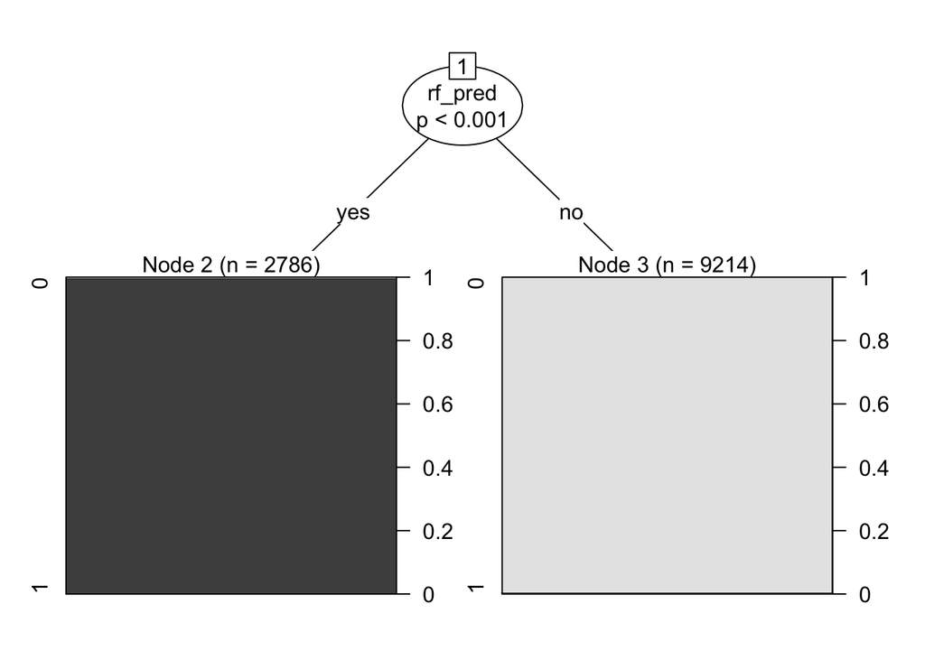

```r
stacked_model <- ctree(train_data$left ~ . + 1, data = model_combined_results, controls = ctree_control(mincriterion = .95)) %T>% plot
```

```r
stacked_model_prediction = predict(stacked_model, stacked_data, type = "response")
accuracy(stacked_model_prediction, test_data$left, "Stacked Model Accuracy")
```

```
## Model: Stacked Model Accuracy had 0.9893298 accuracy
```

```
## [1] 0.9893298
```

```r
a8 = accuracy(stacked_model_prediction, test_data$left, "Stacked Model Accuracy")
```

```
## Model: Stacked Model Accuracy had 0.9893298 accuracy
```

[output not shown]

# Conclusion

```r
acc_predictions = c(a1,a2,a3,a4,a5, a6, a7, a8)
#acc_predictions = c(a1,a2,a3,a4,a5,a6,a7,a8,a9,a10)
#names = c("Log Prediction Plain","Log Boosted","Log Step","SVM with Vanilla Kernal","SVM Radial Basis Kernal","Neural Net One Hidden Node","Neural Net Two Hidden Nodes","CTree Regression","Random Forest Classification","Ada Boost Classification")

names = c("Log Prediction Plain", "SVM with Vanilla Kernal","SVM Radial Basis Kernal","Decision C5.0 Tree Regression","Decision Tree C5.0 Regression trails 10", "Decision Tree C5.0 with Cost Model", "Random Forest", "Stacked Model")
acc_mat <- data.frame(ModelName = names, accuracy = acc_predictions) %>% print
```

```
##                                 ModelName  accuracy
## 1                    Log Prediction Plain 0.5568523
## 2                 SVM with Vanilla Kernal 0.7715905
## 3                 SVM Radial Basis Kernal 0.9486495
## 4           Decision C5.0 Tree Regression 0.9789930
## 5 Decision Tree C5.0 Regression trails 10 0.9806602
## 6      Decision Tree C5.0 with Cost Model 1.0000000
## 7                           Random Forest 0.9893298
## 8                           Stacked Model 0.9893298
```

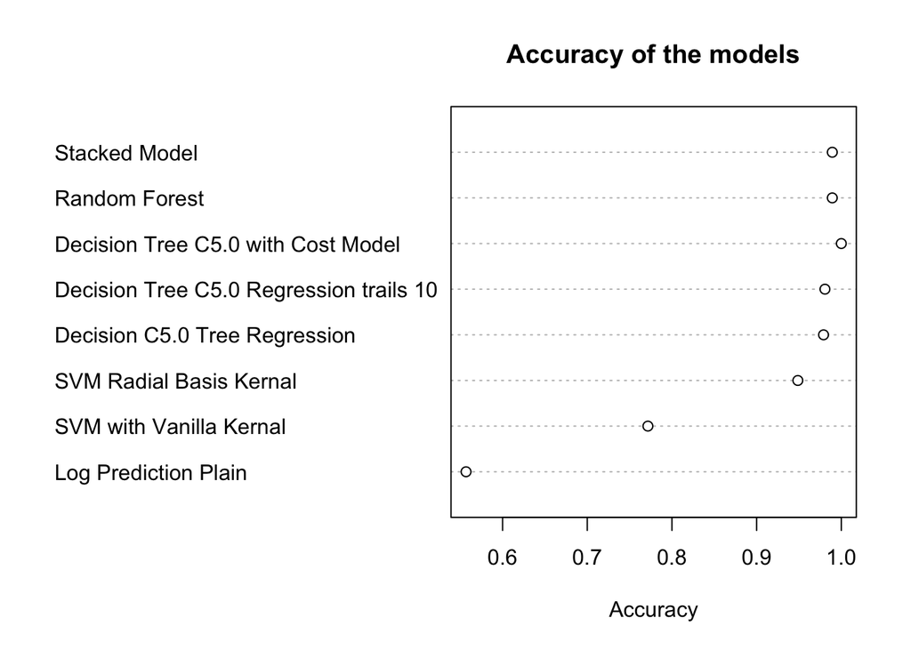

[output not shown]

```r
dotchart(acc_predictions, labels = names, main = "Accuracy of the models", xlab = "Accuracy")
```